# Balanus example - Molecular Ecology

John Wares

3/18/2024

# Why did I put this together?

When you learn how to do this work in a coding environment like **R**, it isn’t just about doing it the nerdy way. Coding scientific research makes it more *repeatable* and *reproducible*. I can go back to some of the analyses from my paper that I finished working on 3 years ago and repeat the analyses exactly – or, if the data changed (say, I added more data), then all of the analyses could be done on the updated data *and the figures would be re-made using the same specifications as before*.

I hope this works - it was working last time I touched it, but now had to re-load a bunch of libraries in March 2024…

## Your assignment

Assuming I put all this together correctly, you should have this .Rmd file and the file May19.snps.gen, accessed via code below. Please note: I’m not a highly skilled coder, there are definitely more sophisticated approaches to all of the outcomes below. However, using this document you can run through each of the analytical steps individually by pressing the ‘play’ button at the top right of each ‘code chunk’.

First, I sampled a lot of individual barnacles from the rocks of the Pacific coast, isolated DNA using a simple and inexpensive lab process, and then prepared a “library” of reduced-representation genomic DNA that could be sequenced so I would have data for each selected part of the genome in enough coverage/replicates that we can see where there are *single nucleotide polymorphisms* within and among individuals (genotypes, allele frequencies).

In the data transformation above, the decision has been made to rather liberally include loci as inferred from sequence data (using the program STACKS, Catchen et al 2017) because there was a large amount of missing data across this sequencing run. So, loci are included with up to 50% missing information from individuals, and individuals included with up to 50% missing information from all loci. These decisions were initially made after considerable data exploration to retain as many individuals and loci as seemed useful for the question; *different questions may require different analytical cutoffs*. The data have been sampled from the locations on this map of the northeastern Pacific coast:

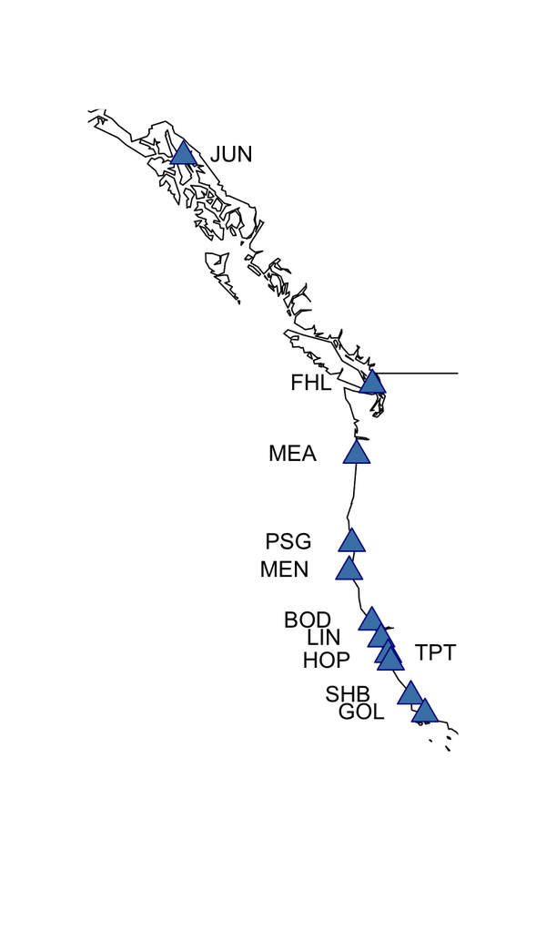

Figure 1. Map of sampled locations.

However, note (**explore the data products in each code chunk**, using console commands like str(XXX) or calling the elements within each data structure, ask Dr. Wares to demonstrate!) that one site (PSG) no longer has any individuals included; the libraries from that source were mishandled in the lab by JPW, apparently, and contributed most of the ‘missing’ information (all sorts of surprises in this kind of work, pay attention in the lab! In this case it is likely that I did not correctly dilute the DNA concentration for those samples)

### **The organism is an acorn barnacle :) meaning adults are sessile, offspring can drift for 10s of kilometers before they settle.** What questions does this raise about how the ocean environment will influence the distribution of diversity in this species?

Let’s first take a close look at the data. Here we have SNPs generated using a restriction-site limited sequencing effort, meaning that only a small subset of the overall genome is sequenced - and thus enough sequences cover each part of each genome that we can determine not only the sequence of each fragment but whether there are polymorphic sites within a fragment. But think about that carefully from the point of view of how you *know* each fragment that is sequenced, in one individual, is the same or different from a similar fragment sequenced in another individual?

In Chapter 4, we started thinking about F-statistics, or the broad family of hierarchical statistics that use different models depending on the marker type to compare diversity in nested ‘containers’ of diversity. I need to go back and unpack one of them a bit. The *inbreeding coefficient* we explored can also be evaluated as Xis: the heterozygosity in an individual relative to the heterozygosity expected for the sample/subpopulation it is within. If an individual contains a lot of homozygous loci despite there being more heterozygosity in the sample, Xis is elevated - it suggests some form of inbreeding. If a locus is consistently elevated in homozygosity across all individuals in the sample, however (relative to all other loci), it may be that what we are ‘seeing’ is an artefact. This is a step where we have to think about the *natural history* of the markers, the process of obtaining marker data, and the *natural history* of the organism as well to consider what we might expect to see.

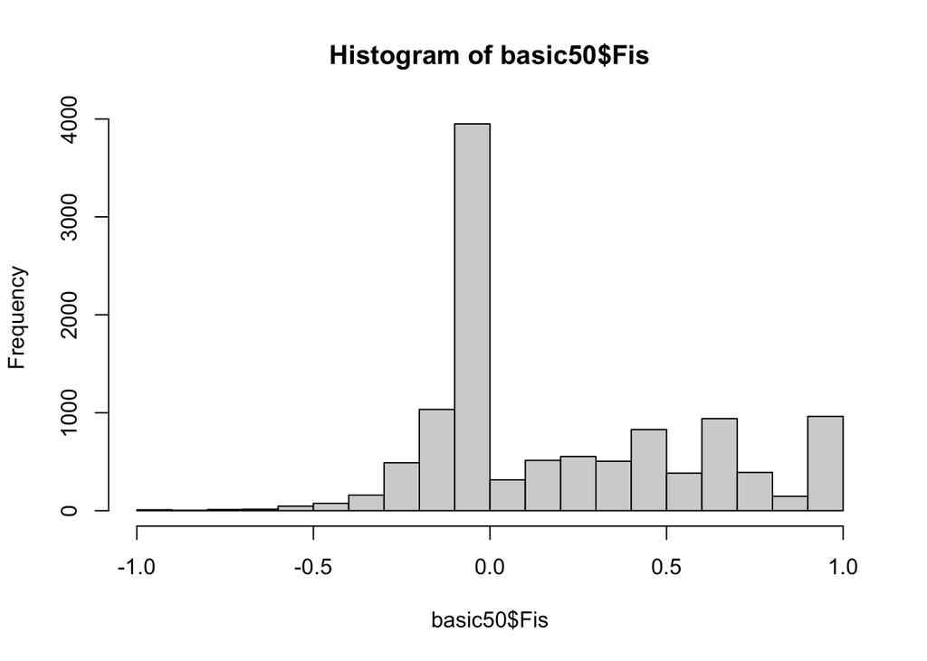

So, choose your own adventure: what do you do now?

1. go back and attempt to rebuild the SNP dataset with different parameters and hope that fixes some of the problems
2. evaluate how to exclude loci that are still behaving in surprising ways, given that you cannot know the truth about any single locus without a tremendous amount of extra work and/or having a well-constructed genome for your species.

Most importantly, take some time to think about how it is important to *look at your data* and learn to intuit how the data are behaving without just blindly plunging into additional analyses. Many of the iterations that are necessary in this kind of science could be avoided if you learn to think carefully about the data first!

This isn’t just a problem that arises with inference of variable loci from a protocol like RAD-seq by the way. Designing primers for microsatellites or other variable loci can often lead to markers that do not appear to fit our expectations of Hardy-Weinberg equilibria, and are typically then excluded.

In the case of this data set, the resultant analyses are not highly dependent on whether the ‘misbehaving’ loci are included or not, but often that will not be the case so it is always good to take a deep breath and spend some time on the data before getting attached to the outcomes of any further analysis.

So, lets now look at the data having trimmed out many of the misbehaving loci:

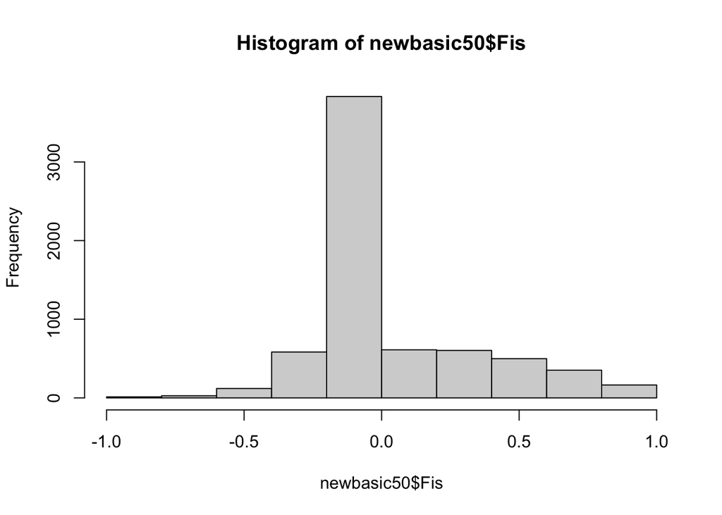

Basically here I have made some decisions about trimming out some loci based on elevated inbreeding coefficients, but not all of them - because at this point, the markers are being looked at across all spatial samples from Alaska to Southern California! If we want to think about patterns of divergence among sites, we would *expect* some loci to be entirely homozygous in some individuals because of where they are, even though the marker is variable across the entire data set. If you aren’t sure if you understand this, go back to Chapter 4 and the discussion of $X_{st}$ - which is itself a measure of inbreeding of the sample relative to the total study!

**Questions for you to answer before next class period**

1. Write a paragraph that explains your understanding of how these data were obtained.
2. Write a paragraph that explains your understanding of how decisions in the assembly of these data can influence the outcome of our analyses.
3. Write a paragraph that explains your understanding of what patterns of data lead to low *X*st, and what lead to high *X*st - and for the data we are using here, what would we replace ‘*X*’ with, and why?
4. Given what you know of the natural history of the organism, what questions does this raise about how the ocean environment will influence the distribution of diversity in this species? What might you predict, overall - use your own words don’t worry about technical language.

This concludes your first day snooping through this data set.

Next, we are exploring overall patterns in these data. Analysis of population genomic data is an exploratory, iterative process - you often have to analyze the data in a first pass to consider what the most useful next considerations are.

```
##         BgJun9 BgFHL9 BgMea48 BgMen9 BgBod9 BgLin9 BgTPt9 BgHop50 BgShB9 BgGol9
## BgJun9      NA 0.0105  0.0570 0.0624 0.0660 0.1069 0.2127  0.2436 0.2959 0.3403
## BgFHL9  0.0105     NA  0.0412 0.0470 0.0525 0.0873 0.1935  0.2244 0.2804 0.3183
## BgMea48 0.0570 0.0412      NA 0.0054 0.0283 0.0609 0.1571  0.1925 0.2449 0.2917
## BgMen9  0.0624 0.0470  0.0054     NA 0.0229 0.0390 0.1271  0.1546 0.2085 0.2490
## BgBod9  0.0660 0.0525  0.0283 0.0229     NA 0.0103 0.0837  0.1018 0.1526 0.1912
## BgLin9  0.1069 0.0873  0.0609 0.0390 0.0103     NA 0.0381  0.0541 0.0968 0.1170
## BgTPt9  0.2127 0.1935  0.1571 0.1271 0.0837 0.0381     NA  0.0038 0.0199 0.0378
## BgHop50 0.2436 0.2244  0.1925 0.1546 0.1018 0.0541 0.0038      NA 0.0128 0.0265
## BgShB9  0.2959 0.2804  0.2449 0.2085 0.1526 0.0968 0.0199  0.0128     NA 0.0082
## BgGol9  0.3403 0.3183  0.2917 0.2490 0.1912 0.1170 0.0378  0.0265 0.0082     NA
```

Remember, the pairwise matrix you just generated uses the population abbreviations in the figure above: ‘Jun’ is Juneau, Alaska; while Gol is Goleta Point, near Santa Barbara, CA. Following generation of pairwise Fst values, lets explore the data using DAPC (discriminant analysis of principal components). This particular code uses the sampling information (location, label) as an element of clustering how diversity of individuals relates to the pattern of diversity overall, so each sample site is colored - do they fit any pattern you can recognize?

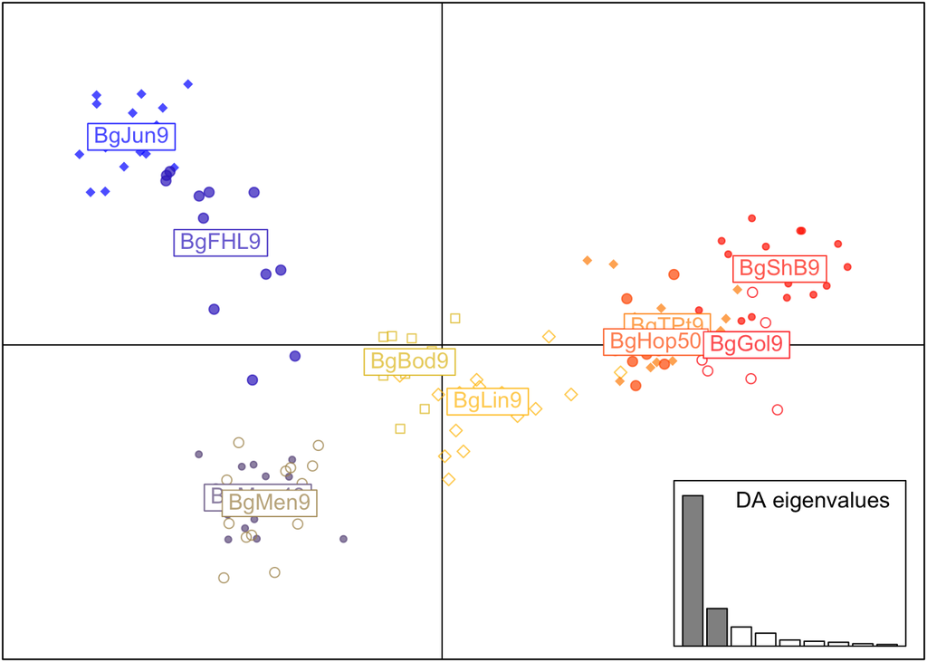

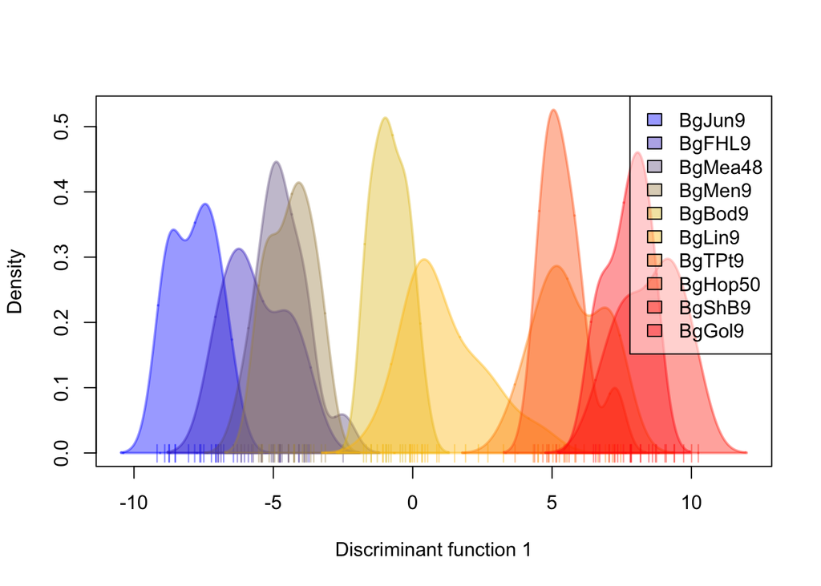

In particular, note that here the populations from north (cooler colors) to south (warmer) are lined up pretty nicely. *Is this isolation-by-distance? Or is there hierarchy? Or is there isolation-by-environment??* Think about that and let’s see if there are other ways to categorize the diversity we see.

Now lets try **snmf**… what does that mean? “*sparse non-negative matrix factorization*”, see http://membres-timc.imag.fr/Olivier.Francois/snmf/index.htm for more details on this. Effectively this is a computationally efficient (linear algebra) way to estimate the “ancestry coefficients” of individuals among a set of *K* populations, as with Structure (Pritchard, 2000; uses Fis as an optimizing criterion to separate sampled genomes into *K* sets.

WAHOOO MAKE SURE THIS CALL AND RESPONSE DOESN’T GO INTO THE HTML OUTPUT, 100s of COMMAND REPEATS… :) not sure which command, worry about that tomorrow.

This next code chunk will take a few minutes - in part because it is repeating one analysis many times to help us “objectively” determine what the statistically-optimal number of populations (K) would be for these data. Also, pay attention that the many repeated analyses in this code chunk have to have their output thoroughly masked if you are trying to write a document, so the header of this following code chunk tells you a few cues for writing .Rmd that makes readable AND repeatable output.

*So we will take this time to talk about repeatability and reproducibility in science, as well as the methods and hypotheses in this study.*

## snmf output

below will be 4 plots, and you can look at the .Rmd to find the code that got us here. The first looks like a funny dot plot and is the mechanism by which SNMF approaches help guide the scientist towards the most appropriate value of *K* ancestral populations for the data to have come from; typically the lowest point is the best, but sometimes as in this plot there may be 2 that are quite similar in their “cross-entropy”. You can think of this as trying to minimize the variance in iterated outcomes of trying to fit the individuals into *K* populations; minimum is better.

Below that are the bar graphs for population composition of each individual, starting in the north to the left and to the south as you move to the right. First is K=2, then K=3, then K=5.

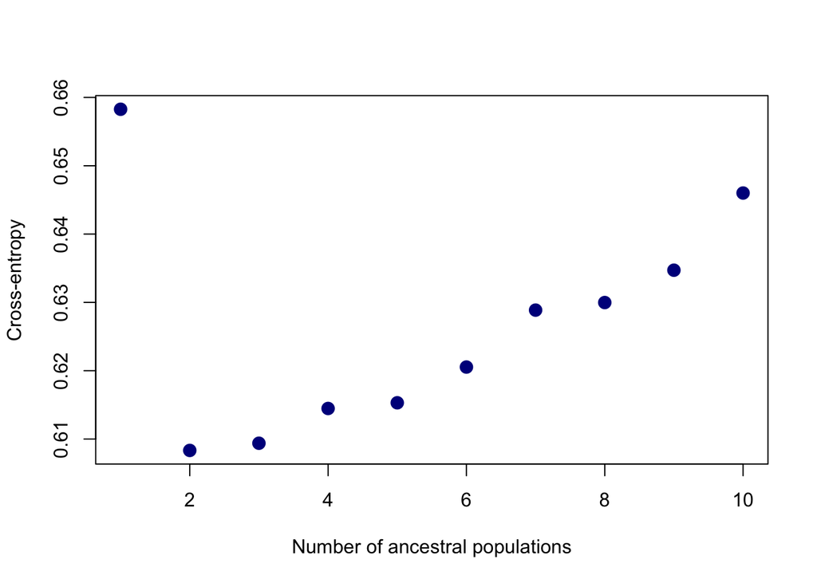

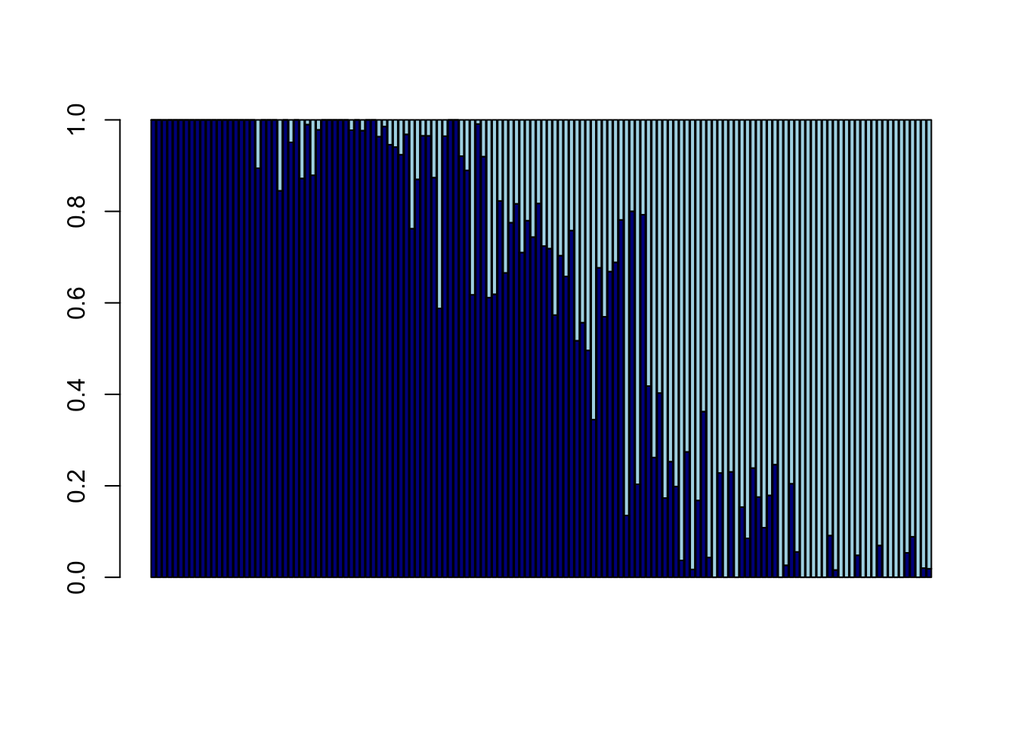

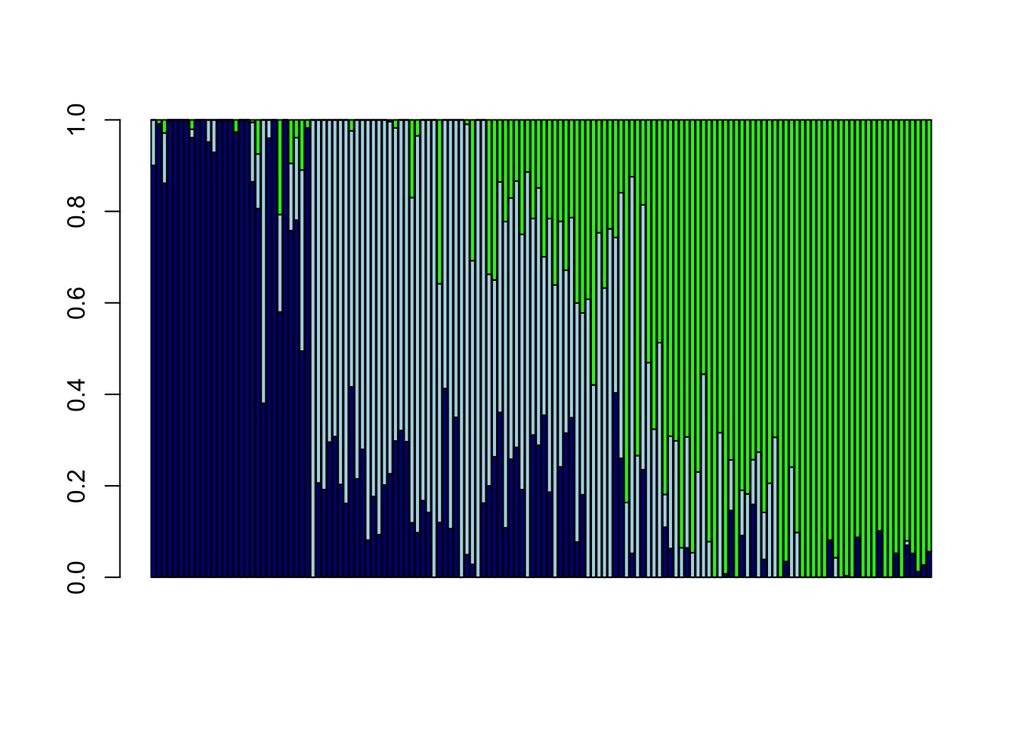

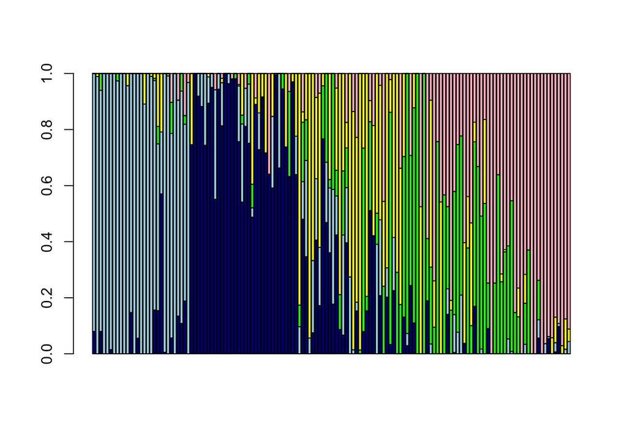

What do these plots begin to tell you about spatial patterns of diversity - what more do you want to know to find out why this pattern exists?

So, that isn’t the whole set of analyses that were done. If you want to know more, the paper is at http://sotkae.people.cofc.edu/Publications_files/WaresStrandSotka2021.pdf where you can directly get the PDF. The focus here was on finding not just that there *is* population spatial structure of genomic data, but identifying some of the mechanisms - which appear to be related to a *region of low habitat availability* interacting with *broader environmental gradients*. Are they two distinct species? No - but they may still function distinctly in some way in these ecosystems. They are definitely a mix of isolation-by-distance, hierarchical diversity, and some evidence for adaptation or divergence in fitness optima, and my work has barely scratched the surface!

*What would you like to add to this base analysis to address questions you may have with multilocus SNP data? Would there be a spatial subset that merits more exploration? What experiment could you establish in south-central California to study the overall pattern further? What experiment could be run at the power generating station in Morro Bay, CA, where the spatial cline is coincident with a warm-water outflow that is very different from surrounding thermal habitats?*